# Assignment 4 Task 2

Nicholas Bissonnette

11/17/2020

## 2.Data and analysis

First I will look at study design and the distribution of collection over time. Then I will look at the difference in weights among the sexes as they relate to the trapping sites. Lastly I will look at the linear relationship between weight and hind foot length of juvenile snowshoe hares. The statiscal tools used are t-tests, effect size, liner models, and regression.

**CITATION**

Kielland, K., F.S. Chapin, R.W. Ruess, and Bonanza Creek LTER. 2017. Snowshoe hare physical data in Bonanza Creek Experimental Forest: 1999-Present ver 22. Environmental Data Initiative. https://doi.org/10.6073/pasta/03dce4856d79b91557d8e6ce2cbcdc14 (Accessed 2020-11-17).

## 3.Exploratory findings

**A.**

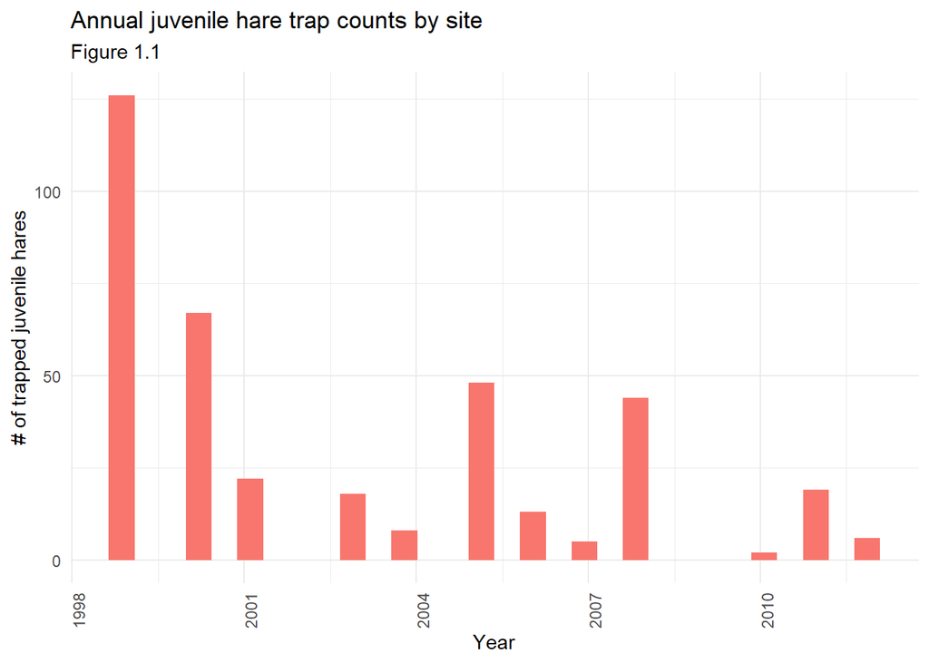

The data tells us that a total of 378 hares were trapped from 1999 -2012. The year with the lowest amount traps was 2010 with 2 and the year with the most traps was 1999 with 126. There are also two years with no data. This data appears to not be normally distributed, with the majority of traps coming in the early years of the study. The mean annual count of traps is 31.5, which is not close to a value that is seen in any individual year.The median value of the annual traps is 18.5. This large difference between median and mode is evidence for none normal distribution.

**B.**

Next, I will create a data visualization to compare juvenile hare weights by sex and site. I will do this making a dataframe of sex, age, weight and grid. Then I will plot that data in a facet version to show each.

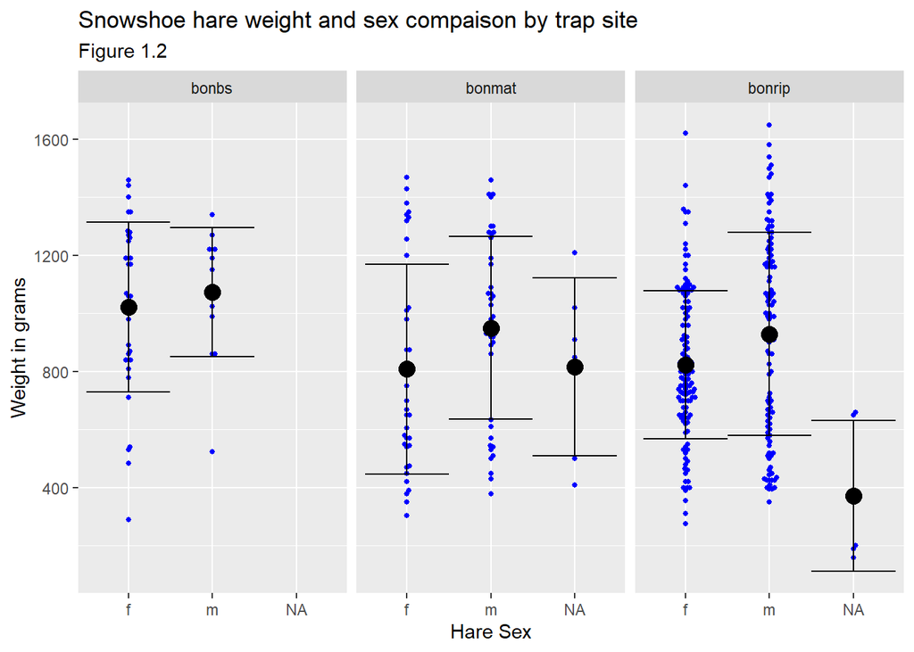

### **Figure 1.2** This shows the weight(grams) compared to hare sex at each of the trap sites.

**C.**

Here I will make a summary statistic table for the hares of the weights. This information can be used to find mean, standard deviation, and sample size of the snowshoe hares.

### **Table 1.1** The below table show the mean, Standard Deviation, and Sample Size of Snowshoe Hare weights broken up by sex.

| Mean, Standard Deviation, and Sample Size of Snowshoe Hare weights sex | Mean, Standard Deviation, and Sample Size of Snowshoe Hare weights mean_weight | Mean, Standard Deviation, and Sample Size of Snowshoe Hare weights sd_weight | Mean, Standard Deviation, and Sample Size of Snowshoe Hare weights sample_size |
| --- | --- | --- | --- |
| f | 855.3909 | 292.2526 | 200 |
| m | 945.8589 | 333.2151 | 163 |
| NA | 614.5455 | 357.5853 | 15 |

**D.**

After running the Two Sample T-test, I can see that the difference in mean weight between female and male snowshoe hares is 90.47. The Cohen’s d test shows a value 0.29 which is a low moderate effect, indicating that there is a difference and it would take effort to study what that difference is. The p-value fro the the t-test is 0.007 which show a relatively low chance that samples came from populations with the same mean.

**E.**

Here I will explore the relationship between juvenile hare weight and hind foot length.

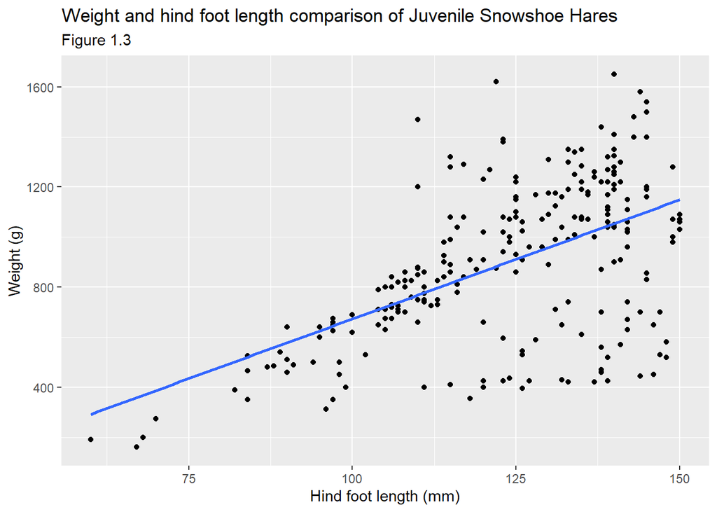

### **Figure 1.3** This figure shows the relationship between hind foot length (mm) and weight (g) of Juvenile Snowshoe Hares across all trap locations.

Pearson’s R will give us the correlation for figure 1.3. I am able to see that the Pearson’s r correlations is 0.55. This value indicates a moderate positive correlation. I would say that the higher the values are for hind foot length and weight, the more the correlation decreases. This indicates that there is a week relationship between weight and hind foot length as the overall size increases.